Date: 20-10-2020 Name: Claudia B.

## Introduction

Using devices such as Jawbone Up, Nike FuelBand, and Fitbit it is now possible to collect a large amount of data about personal activity relatively inexpensively. These type of devices are part of the quantified self movement - a group of enthusiasts who take measurements about themselves regularly to improve their health, to find patterns in their behavior, or because they are tech geeks. One thing that people regularly do is quantify how much of a particular activity they do, but they rarely quantify how well they do it. In this project, your goal will be to use data from accelerometers on the belt, forearm, arm, and dumbell of 6 participants. They were asked to perform barbell lifts correctly and incorrectly in 5 different ways. More information is available from the website here: http://web.archive.org/web/20161224072740/http:/groupware.les.inf.puc-rio.br/har (see the section on the Weight Lifting Exercise Dataset).

The goal of this report is to predict the manner in which they did the exercise. This is the “classe” variable in the training set.

## Loading the data

```r
training_csv <- read.csv('https://d396qusza40orc.cloudfront.net/predmachlearn/pml-training.csv', header = TRUE, sep = ',')
training_raw <- training_csv[,2:ncol(training_csv)]

dim(training_raw)
```

```
## [1] 19622   159
```

## Run the Random Forest Model

```r
RFmodel <- randomForest(classe ~ .,data=training_model)

print(RFmodel)
```

```
##
## Call:
##  randomForest(formula = classe ~ ., data = training_model)
##                Type of random forest: classification
##                      Number of trees: 500
## No. of variables tried at each split: 9
##
##         OOB estimate of  error rate: 0.2%
## Confusion matrix:
##      A    B    C    D    E class.error
## A 3348    0    0    0    0 0.000000000
## B    3 2276    0    0    0 0.001316367
## C    0    8 2044    2    0 0.004868549
## D    0    0    4 1923    3 0.003626943
## E    0    0    0    4 2161 0.001847575
```

## Testing the model

```r
test_pred <- predict(RFmodel, newdata = testing_model[,-ncol(testing_model)])

confMatrix <- confusionMatrix(test_pred,testing_model$classe)
print(confMatrix)
```

```
## Confusion Matrix and Statistics
##
##           Reference
## Prediction    A    B    C    D    E
##          A 2232    5    0    0    0
##          B    0 1513    1    0    0
##          C    0    0 1364    7    0
##          D    0    0    3 1278    2
##          E    0    0    0    1 1440
##
## Overall Statistics
##
##                Accuracy : 0.9976
##                  95% CI : (0.9962, 0.9985)
##     No Information Rate : 0.2845
##     P-Value [Acc > NIR] : < 2.2e-16
##
##                   Kappa : 0.9969
##
##  Mcnemar's Test P-Value : NA
##
## Statistics by Class:
##
##                      Class: A Class: B Class: C Class: D Class: E
## Sensitivity            1.0000   0.9967   0.9971   0.9938   0.9986
## Specificity            0.9991   0.9998   0.9989   0.9992   0.9998
## Pos Pred Value         0.9978   0.9993   0.9949   0.9961   0.9993
## Neg Pred Value         1.0000   0.9992   0.9994   0.9988   0.9997
## Prevalence             0.2845   0.1935   0.1744   0.1639   0.1838
## Detection Rate         0.2845   0.1928   0.1738   0.1629   0.1835
## Detection Prevalence   0.2851   0.1930   0.1747   0.1635   0.1837
## Balanced Accuracy      0.9996   0.9983   0.9980   0.9965   0.9992
```

The accuracy is of 99.7% which is very high. The model performs well!

### We look at the feature importance

The feature importance is printed and then plotted.

```r
importance(RFmodel)
```

```
##                         MeanDecreaseGini
## user_name                    49.34403083
## raw_timestamp_part_1        950.49597485
## raw_timestamp_part_2         15.46342676
## cvtd_timestamp              539.95250810
## new_window                    0.11083404
## num_window                  580.73318144
## roll_belt                   556.72064934
## pitch_belt                  298.25995936
## yaw_belt                    383.04158459
## total_accel_belt            128.29626311
## kurtosis_roll_belt            0.29714952
## kurtosis_picth_belt           0.25489161
## kurtosis_yaw_belt             0.09830633
## skewness_roll_belt            0.30661320
## skewness_roll_belt.1          0.38886465
## skewness_yaw_belt             0.16266654
## max_yaw_belt                  0.18904365
## min_yaw_belt                  0.27201556
## amplitude_yaw_belt            0.13244529
## gyros_belt_x                 46.90874560
## gyros_belt_y                 56.82893554
## gyros_belt_z                147.64018392
## accel_belt_x                 70.57941607
## accel_belt_y                 70.15679750
## accel_belt_z                196.63031437
## magnet_belt_x               118.38559356
## magnet_belt_y               214.52222225
## magnet_belt_z               183.40209094
## roll_arm                    144.73084233
## pitch_arm                    72.73000900
## yaw_arm                      95.53805172
## total_accel_arm              41.54586517
## gyros_arm_x                  56.51937632
## gyros_arm_y                  59.06412328
## gyros_arm_z                  28.56836811
## accel_arm_x                 129.84694864
## accel_arm_y                  70.07261659
## accel_arm_z                  58.41651648
## magnet_arm_x                132.24962781
```

[output cut: 37 more lines]

```
## skewness_pitch_forearm        0.23332563
## skewness_yaw_forearm          0.10594870
## max_yaw_forearm               0.18650498
## min_yaw_forearm               0.24467333
## amplitude_yaw_forearm         0.10669321
## total_accel_forearm          42.56906204
## gyros_forearm_x              34.71139670
## gyros_forearm_y              54.03768161
## gyros_forearm_z              37.13674189
## accel_forearm_x             155.41719694
## accel_forearm_y              57.12471550
## accel_forearm_z             111.32102049
## magnet_forearm_x             95.77102372
## magnet_forearm_y             91.34301265
## magnet_forearm_z            116.19010685
```

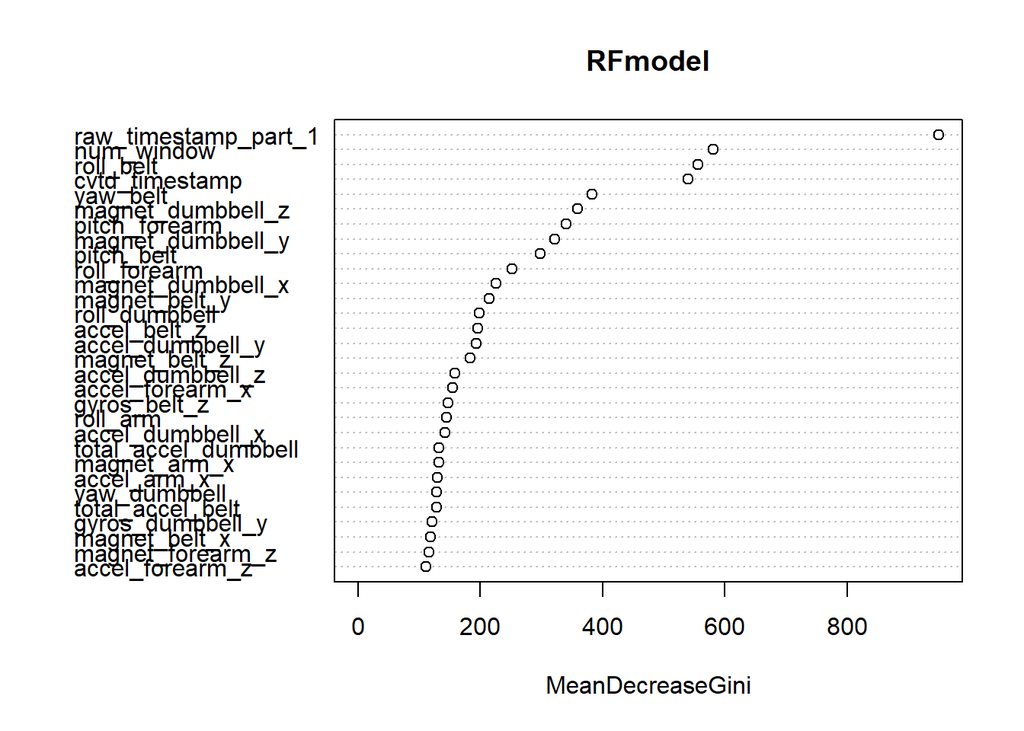

```r
varImpPlot(RFmodel,type=2)
```

The variables are sorted by importance, meaning that the variables at the top of the plot explain more of the variance/and therefore of the information contained in the data.

```r
testing_raw <- read.csv('https://d396qusza40orc.cloudfront.net/predmachlearn/pml-testing.csv', header = TRUE, sep = ',',na.strings=c("NA",""))
testing <- testing_raw[,-1] # Remove the first column that represents a ID Row
testing <- testing[ , cols] # Keep the same columns of testing dataset
testing <- testing[,-ncol(testing)] # Remove the problem ID

# Apply the ID Row to row.names and 100 for dummy row from testing dataset
predictions <- predict(RFmodel,testing)
predictions
```

```
##  [1] <NA> <NA> <NA> <NA> <NA> <NA> <NA> <NA> <NA> <NA> <NA> <NA> <NA> <NA> <NA>
## [16] <NA> <NA> <NA> <NA> <NA>
## Levels: A B C D E
```